# Project 2 Solution

Ananya Bhaktaram

September 29th, 2024

# Part 1: Fun with functions

### Part 1A: Exponential transformation

The exponential of a number can be written as an infinite series expansion of the form
$$\exp(x) = 1 + x + \frac{x^2}{2!} + \frac{x^3}{3!} + \cdots$$
Of course, we cannot compute an infinite series by the end of this term and so we must truncate it at a certain point in the series. The truncated sum of terms represents an approximation to the true exponential, but the approximation may be usable.

Write a function that computes the exponential of a number using the truncated series expansion. The function should take two arguments:

- `x`: the number to be exponentiated
- `k`: the number of terms to be used in the series expansion beyond the constant 1. The value of `k` is always $\geq 1$.

For example, if $k = 1$, then the `Exp` function should return the number $1 + x$. If $k = 2$, then you should return the number $1 + x + x^2/2!$.

Include at least one example of output using your function.

- You can assume that the input value `x` will always be a *single* number.
- You can assume that the value `k` will always be an integer $\geq 1$.
- Do not use the `exp()` function in R.
- The `factorial()` function can be used to compute factorials.

```r
Exp <- function(x, k) {
  result <- 1 # Initialize with the first term 1
  term <- 1 # Initialize term value (to handle x^0/0!=1)

  for (n in 1:k) {
    term <- term * (x/n) # Updates the term as x^n/n!
    result <- result + term # Adds each term to the final result
  }
   return (result) # Add your solution here
}

# Example Output
Exp (2,5)
```

```
## [1] 7.266667
```

```r
# Long form equation of exponential series using 2 as the number being exponentiated and 5 as the number of terms in the series expansion beyond the constant, as proof that the function work
1 + 2 + (2^2 / factorial(2)) + (2^3 / factorial(3)) + (2^4 / factorial(4)) + (2^5 / factorial(5))
```

```
## [1] 7.266667
```

### Part 1B: Sample mean and standard deviation

Next, write two functions called `sample_mean()` and `sample_sd()` that takes as input a vector of data of length $N$ and calculates the sample average and sample standard deviation for the set of $N$ observations.

$$\bar{x} = \frac{1}{N} \sum_{i=1}^n x_i$$
$$s = \sqrt{\frac{1}{N-1} \sum_{i=1}^N (x_i - \overline{x})^2}$$
As a primer, the $\sum_{i = 1}^3 x_i$ is equivalent to doing the sum of $x_i$ starting from $i = 1$, increasing $i$ by 1 each then, up to when $i = 3$. That is, $x_1 + x_2 + x_3$.

Include at least one example of output using your functions.

- You can assume that the input value `x` will always be a *vector* of numbers of length *N*.
- Do not use the `mean()` and `sd()` functions in R.

```r
# Function to calculate sample mean
sample_mean <- function(x) {
  N<- length(x) # The number of elements in the vector
  sum_x <- sum(x) # The sum of all elements in the vector
  mean_x <- sum_x / N # Formula to calculate the sample mean
  return (mean_x) # Return the mean
}

# Create vector to store test data
test_data <- c(10, 11, 12, 13, 14, 15, 16, 17)

# Calculate Sample mean
test_mean <- sample_mean(test_data)
print(test_mean)
```

```
## [1] 13.5
```

```r
# Long form calculation of sample mean to prove the function works
(10 + 11 + 12 + 13 + 14 + 15 + 16 + 17)/ 8
```

```
## [1] 13.5
```

```r
# Function to calculate sample standard deviation
sample_sd <- function(x) {
  N <- length(x) # Number of elements in the vector
  mean_x <- sample_mean(x) # Use the sample_mean function to determine the sample mean
  sum_squared_diff<- sum((x - mean_x)^2) # Sum of squared differences from the mean
  sd_x <- sqrt(sum_squared_diff / (N -1)) # Sample standard deviation formula
  return(sd_x)
}

# Calculate sample standard deviation
test_sd <- sample_sd(test_data)
print(test_sd)
```

```
## [1] 2.44949
```

```r
# Check using the sd() function in R
sd(test_data)
```

```
## [1] 2.44949
```

### Part 1C: Confidence intervals

Next, write a function called `calculate_CI()` that:

1. There should be two inputs to the `calculate_CI()`. First, it should take as input a vector of data of length $N$. Second, the function should also have a `conf` ($=1-\alpha$) argument that allows the confidence interval to be adapted for different $\alpha$.
2. Calculates a confidence interval (CI) (e.g. a 95% CI) for the estimate of the mean in the population. If you are not familiar with confidence intervals, it is an interval that contains the population parameter with probability $1-\alpha$ taking on this form

$$\bar{x} \pm t_{\alpha/2, N-1} s_{\bar{x}}
= ( \bar{x} - t_{\alpha/2, N-1} s_{\bar{x}}, \bar{x} + t_{\alpha/2, N-1}
s_{\bar{x}} )$$

where $t_{\alpha/2, N-1}$ is the value needed to generate an area of $\alpha / 2$ in each tail of the $t$-distribution with $N-1$ degrees of freedom and $s_{\bar{x}} = \frac{s}{\sqrt{N}}$ is the standard error of the mean. For example, if we pick a 95% confidence interval and $N$=50, then you can calculate $t_{\alpha/2, N-1}$ as

```r
alpha <- 1 - 0.95
degrees_freedom <- 50 - 1
t_score <- qt(p = alpha / 2, df = degrees_freedom, lower.tail = FALSE)
```

3. Returns a named vector of length 2, where the first value is the `lower_bound`, the second value is the `upper_bound`.

```r
# Function to calculate confidence interval for the population mean
calculate_CI <- function(x, conf = 0.95) {

  N <- length(x)                   # Sample size; number of elements in the vector
  mean_x <- sum(x) / N             # Sample mean
  sd <- sqrt(sum((x - mean_x)^2) / (N - 1))  # Sample standard deviation
  se_x <- sd / sqrt(N)              # Standard error of the mean

  alpha <- 1 - conf                # Alpha level
  t_score <- qt(p = alpha / 2, df = N - 1, lower.tail = FALSE)  # t-score value

  # Confidence interval calculation
  lower_bound <- mean_x - t_score * se_x
  upper_bound <- mean_x + t_score * se_x

  # Return a named vector with the lower and upper bounds
  return(c(lower_bound = lower_bound, upper_bound = upper_bound))
}

# Calculate the 95% confidence interval using the test data
created_CI <- calculate_CI(test_data, conf = 0.95)

# Check function output
dat <- data.frame(test_data = test_data) # This fits a linear model with no predictors (intercept only)
fit <- lm(test_data ~ 1, dat)

# Calculate a 95% confidence interval
CI_lm <- confint(fit, level = 0.95)

# Compare the results between the two functions
print("Manually Created CI Function:")
```

```
## [1] "Manually Created CI Function:"
```

```r
print(created_CI)
```

```
## lower_bound upper_bound
##    11.45218    15.54782
```

```r
print("confint() CI from linear model:")
```

```
## [1] "confint() CI from linear model:"
```

```r
print(CI_lm)
```

```
##                2.5 %   97.5 %
## (Intercept) 11.45218 15.54782
```

# Part 2: Wrangling data

In this part, we will practice our wrangling skills with the tidyverse that we learned about in module 1.

### Data

The two datasets for this part of the assignment comes from [TidyTuesday](https://www.tidytuesday.com). Specifically, we will use the following data from January 2020, which I have provided for you below:

```r
tuesdata <- tidytuesdayR::tt_load("2020-01-07")
rainfall <- tuesdata$rainfall
temperature <- tuesdata$temperature
```

However, to avoid re-downloading data, we will check to see if those files already exist using an `if()` statement:

```r
library(here)
if (!file.exists(here("data", "tuesdata_rainfall.RDS"))) {
    tuesdata <- tidytuesdayR::tt_load("2020-01-07")
    rainfall <- tuesdata$rainfall
    temperature <- tuesdata$temperature

    # save the files to RDS objects
    saveRDS(tuesdata$rainfall, file = here("data", "tuesdata_rainfall.RDS"))
    saveRDS(tuesdata$temperature, file = here("data", "tuesdata_temperature.RDS"))
}
```

The above code will only run if it cannot find the path to the `tuesdata_rainfall.RDS` on your computer. Then, we can just read in these files every time we knit the R Markdown, instead of re-downloading them every time.

Let’s load the datasets

```r
rainfall <- readRDS(here("data", "tuesdata_rainfall.RDS"))
temperature <- readRDS(here("data", "tuesdata_temperature.RDS"))
```

Now we can look at the data with `glimpse()`

```r
library(tidyverse)

glimpse(rainfall)
```

```
## Rows: 179,273
## Columns: 11
## $ station_code <chr> "009151", "009151", "009151", "009151", "009151", "009151…
## $ city_name    <chr> "Perth", "Perth", "Perth", "Perth", "Perth", "Perth", "Pe…
## $ year         <dbl> 1967, 1967, 1967, 1967, 1967, 1967, 1967, 1967, 1967, 196…
## $ month        <chr> "01", "01", "01", "01", "01", "01", "01", "01", "01", "01…
## $ day          <chr> "01", "02", "03", "04", "05", "06", "07", "08", "09", "10…
## $ rainfall     <dbl> NA, NA, NA, NA, NA, NA, NA, NA, NA, NA, NA, NA, NA, NA, N…
## $ period       <dbl> NA, NA, NA, NA, NA, NA, NA, NA, NA, NA, NA, NA, NA, NA, N…
## $ quality      <chr> NA, NA, NA, NA, NA, NA, NA, NA, NA, NA, NA, NA, NA, NA, N…
## $ lat          <dbl> -31.96, -31.96, -31.96, -31.96, -31.96, -31.96, -31.96, -…
## $ long         <dbl> 115.79, 115.79, 115.79, 115.79, 115.79, 115.79, 115.79, 1…
## $ station_name <chr> "Subiaco Wastewater Treatment Plant", "Subiaco Wastewater…
```

```r
glimpse(temperature)
```

```
## Rows: 528,278
## Columns: 5
## $ city_name   <chr> "PERTH", "PERTH", "PERTH", "PERTH", "PERTH", "PERTH", "PER…
## $ date        <date> 1910-01-01, 1910-01-02, 1910-01-03, 1910-01-04, 1910-01-0…
## $ temperature <dbl> 26.7, 27.0, 27.5, 24.0, 24.8, 24.4, 25.3, 28.0, 32.6, 35.9…
## $ temp_type   <chr> "max", "max", "max", "max", "max", "max", "max", "max", "m…
## $ site_name   <chr> "PERTH AIRPORT", "PERTH AIRPORT", "PERTH AIRPORT", "PERTH …
```

If we look at the [TidyTuesday github repo](https://github.com/rfordatascience/tidytuesday/tree/master/data/2020#2020-data) from 2020, we see this dataset contains temperature and rainfall data from Australia.

Here is a data dictionary for what all the column names mean:

- https://github.com/rfordatascience/tidytuesday/blob/master/data/2020/2020-01-07/readme.md#data-dictionary

### Tasks

Using the `rainfall` and `temperature` data, perform the following steps and create a new data frame called `df`:

1. Start with `rainfall` dataset and drop any rows with NAs.
2. Create a new column titled `date` that combines the columns `year`, `month`, `day` into one column separated by “-”. (e.g. “2020-01-01”). This column should not be a character, but should be recognized as a date. (**Hint**: check out the `ymd()` function in `lubridate` R package). You will also want to add a column that just keeps the `year`.
3. Using the `city_name` column, convert the city names (character strings) to all upper case.
4. Join this wrangled rainfall dataset with the `temperature` dataset such that it includes only observations that are in both data frames. (**Hint**: there are two keys that you will need to join the two datasets together). (**Hint**: If all has gone well thus far, you should have a dataset with 83,964 rows and 13 columns).
- You may need to use functions outside these packages to obtain this result, in particular you may find the functions `drop_na()` from `tidyr` and `str_to_upper()` function from `stringr` useful.

```r
# Step 1 - Dropping NAs from rainfall data
df <- rainfall %>%
  drop_na()

# Check the data frame to ensure that NAs were dropped
head(df)
```

```
## # A tibble: 6 × 11
##   station_code city_name  year month day   rainfall period quality   lat  long
##   <chr>        <chr>     <dbl> <chr> <chr>    <dbl>  <dbl> <chr>   <dbl> <dbl>
## 1 009151       Perth      1967 07    05         2.8      1 Y       -32.0  116.
## 2 009151       Perth      1967 07    06         4.8      1 Y       -32.0  116.
## 3 009151       Perth      1967 07    07         5.8      1 Y       -32.0  116.
## 4 009151       Perth      1967 07    10        16        1 Y       -32.0  116.
## 5 009151       Perth      1967 07    11         1        1 Y       -32.0  116.
## 6 009151       Perth      1967 07    14         1        1 Y       -32.0  116.
## # ℹ 1 more variable: station_name <chr>
```

```r
# Step 2 - Create a new date column
df <- df %>%
  mutate(date = ymd(paste(year, month, day, sep = "-"))) %>%
    select(-month, -day) # This creates a column that just stores the year


# Check that changes were made in the data frame
head(df)
```

```
## # A tibble: 6 × 10
##   station_code city_name  year rainfall period quality   lat  long station_name
##   <chr>        <chr>     <dbl>    <dbl>  <dbl> <chr>   <dbl> <dbl> <chr>
## 1 009151       Perth      1967      2.8      1 Y       -32.0  116. Subiaco Wast…
## 2 009151       Perth      1967      4.8      1 Y       -32.0  116. Subiaco Wast…
## 3 009151       Perth      1967      5.8      1 Y       -32.0  116. Subiaco Wast…
## 4 009151       Perth      1967     16        1 Y       -32.0  116. Subiaco Wast…
## 5 009151       Perth      1967      1        1 Y       -32.0  116. Subiaco Wast…
## 6 009151       Perth      1967      1        1 Y       -32.0  116. Subiaco Wast…
## # ℹ 1 more variable: date <date>
```

```r
# Step 3 - Convert the city names (character strings) to all upper case

# Convert city names to upper case
df <- df%>%
  mutate(city_name = toupper(city_name))

# Check data frame for changes
head(df)
```

```
## # A tibble: 6 × 10
##   station_code city_name  year rainfall period quality   lat  long station_name
##   <chr>        <chr>     <dbl>    <dbl>  <dbl> <chr>   <dbl> <dbl> <chr>
## 1 009151       PERTH      1967      2.8      1 Y       -32.0  116. Subiaco Wast…
## 2 009151       PERTH      1967      4.8      1 Y       -32.0  116. Subiaco Wast…
## 3 009151       PERTH      1967      5.8      1 Y       -32.0  116. Subiaco Wast…
## 4 009151       PERTH      1967     16        1 Y       -32.0  116. Subiaco Wast…
## 5 009151       PERTH      1967      1        1 Y       -32.0  116. Subiaco Wast…
## 6 009151       PERTH      1967      1        1 Y       -32.0  116. Subiaco Wast…
## # ℹ 1 more variable: date <date>
```

```r
# Step 3 - Join rainfall data set with the temperature data set

# Load dplyr
library(dplyr)

# Join rainfall with temperature data
combined_df <- df %>%
  inner_join(temperature, by = c("date" = "date", "city_name" = "city_name"))
# Check the data frame to ensure that they are combined
glimpse(combined_df)
```

```
## Rows: 83,964
## Columns: 13
## $ station_code <chr> "009151", "009151", "009151", "009151", "009151", "009151…
## $ city_name    <chr> "PERTH", "PERTH", "PERTH", "PERTH", "PERTH", "PERTH", "PE…
## $ year         <dbl> 1967, 1967, 1967, 1967, 1967, 1967, 1967, 1967, 1967, 196…
## $ rainfall     <dbl> 2.8, 2.8, 4.8, 4.8, 5.8, 5.8, 16.0, 16.0, 1.0, 1.0, 1.0, …
## $ period       <dbl> 1, 1, 1, 1, 1, 1, 1, 1, 1, 1, 1, 1, 1, 1, 1, 1, 1, 1, 1, …
## $ quality      <chr> "Y", "Y", "Y", "Y", "Y", "Y", "Y", "Y", "Y", "Y", "Y", "Y…
## $ lat          <dbl> -31.96, -31.96, -31.96, -31.96, -31.96, -31.96, -31.96, -…
## $ long         <dbl> 115.79, 115.79, 115.79, 115.79, 115.79, 115.79, 115.79, 1…
## $ station_name <chr> "Subiaco Wastewater Treatment Plant", "Subiaco Wastewater…
## $ date         <date> 1967-07-05, 1967-07-05, 1967-07-06, 1967-07-06, 1967-07-…
## $ temperature  <dbl> 17.8, 8.7, 18.4, 8.0, 17.2, 10.5, 16.1, 4.4, 16.8, 4.1, 2…
## $ temp_type    <chr> "max", "min", "max", "min", "max", "min", "max", "min", "…
## $ site_name    <chr> "PERTH AIRPORT", "PERTH AIRPORT", "PERTH AIRPORT", "PERTH…
```

```r
# Check the dimensions of the data set to ensure the data set has 83,964 rows and 13 columns
dim(combined_df)
```

```
## [1] 83964    13
```

# Part 3: Data visualization

In this part, we will practice our `ggplot2` plotting skills within the tidyverse starting with our wrangled `df` data from Part 2. For full credit in this part (and for all plots that you make), your plots should include:

1. An overall title for the plot and a subtitle summarizing key trends that you found. Also include a caption in the figure.
2. There should be an informative x-axis and y-axis label.

Consider playing around with the `theme()` function to make the figure shine, including playing with background colors, font, etc.

### Part 3A: Plotting temperature data over time

Use the functions in `ggplot2` package to make a line plot of the max and min temperature (y-axis) over time (x-axis) for each city in our wrangled data from Part 2. You should only consider years 2014 and onwards. For full credit, your plot should include:

1. For a given city, the min and max temperature should both appear on the plot, but they should be two different colors.
2. Use a facet function to facet by `city_name` to show all cities in one figure.

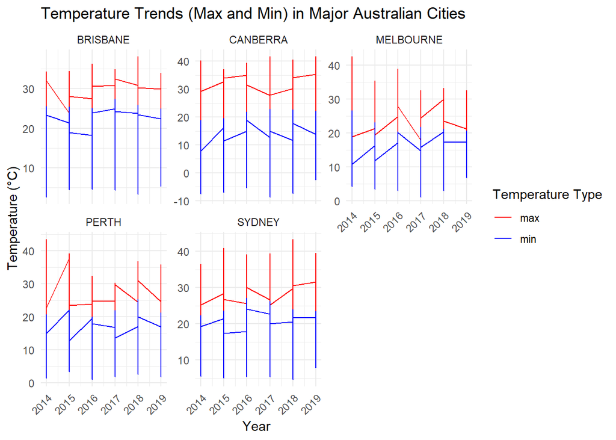

```r
# Load ggplot2
library(ggplot2)

# Filter data to only include data from 2014 onward
filtered_data <- combined_df %>%
  filter(year(date) >= 2014)

# Create line plots
ggplot(filtered_data, aes(x = year, y = temperature, color = temp_type)) +
  geom_line() +
  labs(
    title = "Temperature Trends (Max and Min) in Major Australian Cities",
    x = "Year",
    y = "Temperature (°C)",
    color = "Temperature Type"
  ) +
  facet_wrap(~ city_name, scales = "free_y") +  # Display data by each city
  theme_minimal() +  # Use a minimal theme
  scale_color_manual(values = c("max" = "red", "min" = "blue")) +  # Different colors for max and min
  scale_x_continuous(breaks = seq(2014, max(filtered_data$year), by = 1)) +  # Set breaks for years
  theme(axis.text.x = element_text(angle = 45, hjust = 1))  # Rotate x-axis text for better readability
```

### Part 3B: Plotting rainfall over time

Here we want to explore the distribution of rainfall (log scale) with histograms for a given city (indicated by the `city_name` column) for a given year (indicated by the `year` column) so we can make some exploratory plots of the data.

You are again using the wrangled data from Part 2.

The following code plots the data from one city (`city_name == "PERTH"`) in a given year (`year == 2000`).

```r
df %>%
    filter(city_name == "PERTH", year == 2000) %>%
    ggplot(aes(log(rainfall))) +
    geom_histogram()
```

While this code is useful, it only provides us information on one city in one year. We could cut and paste this code to look at other cities/years, but that can be error prone and just plain messy.

The aim here is to **design** and **implement** a function that can be re-used to visualize all of the data in this dataset.

1. There are 2 aspects that may vary in the dataset: The **city_name** and the **year**. Note that not all combinations of `city_name` and `year` have measurements.
2. Your function should take as input two arguments **city_name** and **year**.
3. Given the input from the user, your function should return a **single** histogram for that input. Furthermore, the data should be **readable** on that plot so that it is in fact useful. It should be possible visualize the entire dataset with your function (through repeated calls to your function).
4. If the user enters an input that does not exist in the dataset, your function should catch that and report an error (via the `stop()` function).

For this section,

1. Write a short description of how you chose to design your function and why.
2. Present the code for your function in the R markdown document.
3. Include at least one example of output from your function.

[output not shown]

[figure not shown]

```r
# Load necessary libraries
library (ggplot2)
library (dplyr)

# Define a function that returns a histogram for rainfall in a city over the course of a single year.
# Load necessary libraries
plot_rainfall_histogram <- function(data, city_name, year) {
  # Print input parameters for debugging
  print(paste("Filtering for City:", city_name, "Year:", year))

  # Check the actual values in the columns
  print(unique(data$city_name))
  print(unique(data$year))

  # Filter the data for the specified city and year
  filtered_rainfall_data <- data %>%
    filter(city_name == !!city_name, year == as.numeric(year))  # Ensure year is numeric

  # Debug: Print the filtered data to confirm it's correct
  print(paste("Total rows in dataset:", nrow(data)))
  print(paste("Filtered Data Count:", nrow(filtered_rainfall_data)))
  print(head(filtered_rainfall_data))  # Show the first few rows of the filtered data

  # Check if any data is available for the specified parameters
  if (nrow(filtered_rainfall_data) == 0) {
    stop("The specified city and year combination does not exist in the dataset.")
  }

  # Create the histogram
  ggplot(filtered_rainfall_data, aes(log(rainfall))) +
    geom_histogram(binwidth = 1, fill = "blue", color = "black", na.rm = TRUE) +
    labs(
      title = paste("Rainfall Distribution in", city_name, "for the Year", year),
      x = "Rainfall (Log Scale)",
      y = "Frequency"
    ) +
    theme_minimal() +
    geom_vline(aes(xintercept = 0), color = "red", linetype = "dashed") +  # Line for drought indicator
    annotate("text", x = 0, y = max(table(filtered_rainfall_data$rainfall), na.rm = TRUE), label = "Drought Indicator", color = "red", vjust = -1)
}

# Example of function usage
plot_rainfall_histogram (df, "PERTH", 2008) # histogram of rainfall in Perth in 2008
```

[output not shown]

[figure not shown]

```r
plot_rainfall_histogram(df, "SYDNEY", 2019) # histogram of rain in Sydney in 2019
```

[output not shown]

[figure not shown]

```r
plot_rainfall_histogram(df,"BRISBANE", 1967) # histogram of rainfall in brisbane in 1967
```